# Workflow to Develop and Validate a Prediction model with `mice` and `psfmi`

Martijn W Heymans

2020-09-24

# Introduction

This vignette shows how to develop, internally and externally validate a (logistic) regression prediction model with `mice` and `psfmi`.

# Steps

- Step 1 - Install the psfmi and mice package
- Step 2 - Impute the missing data with mice
- Step 3 - Develop the model
- Step 4 - Internally validate the model
- Step 5 - Shrink pooled coefficients and determine new intercept
- Step 6 - Externally validate the model

## Step 1 - Install the psfmi and mice package

You can install the released version of psfmi with:

```r
install.packages("psfmi")
```

And the development version from [GitHub](https://github.com/) with:

```r
# install.packages("devtools")
devtools::install_github("mwheymans/psfmi")
```

You can install the released version of mice with:

```r
install.packages("mice")
```

Back to Steps

## Step 2 - Impute the missing data with mice

I generated 5 imputed datasets to handle the missing values in the lbp_orig dataset that is included in the `psfmi` package. Depending on the amount of missing data, the number of imputed datasets may be increased (see on-line book: [Applied Missing Data analysis](https://bookdown.org/mwheymans/bookmi/multiple-imputation.html#number-of-imputed-datasets-and-iterations)).

```r
  library(mice)
  library(psfmi)

  imp <- mice(lbp_orig, m=5, maxit=10)
```

Use the `complete` function of the `mice` package to extract the completed datasets. By setting `action = "long"` and `include = FALSE`, the imputed datasets are stacked under each other to form one long dataset and the original dataset (that included missing values) is not included in that long dataset.

```r
  library(mice)

  data_comp <- complete(imp, action = "long", include = FALSE)
```

Back to Steps

## Step 3 - Develop the model

```r
  library(psfmi)

  pool_lr <- psfmi_lr(data=data_comp, nimp=5, impvar=".imp", Outcome="Chronic",
  predictors=c("Gender", "Age", "JobControl", "Tampascale", "Pain", "Radiation",
  "JobDemands", "SocialSupport", "Smoking"), cat.predictors = c("Satisfaction", "Carrying"),
  spline.predictors = "Function", nknots = 3,
  keep.predictors = "Radiation", p.crit = 0.157, method="D1", direction = "BW")
```

```
## Removed at Step 1 is - Gender
```

```
## Removed at Step 2 is - JobDemands
```

```
## Removed at Step 3 is - Smoking
```

```
## Removed at Step 4 is - Age
```

```
## Removed at Step 5 is - rcs(Function,3)
```

```
## Removed at Step 6 is - JobControl
```

```
## Removed at Step 7 is - SocialSupport
```

```
## Removed at Step 8 is - Tampascale
```

```
##
## Selection correctly terminated,
## No more variables removed from the model
```

```r
  pool_lr$RR_model_final
```

```
## $`Step 9`
##                    term   estimate std.error  statistic        df      p.value
## 1           (Intercept) -5.4555864 1.0533349 -5.1793466  80.89631 1.596456e-06
## 2                  Pain  0.9066812 0.1912409  4.7410420  36.76855 3.169734e-05
## 3             Radiation  0.4783856 0.4964348  0.9636423 130.77651 3.370038e-01
## 4 factor(Satisfaction)2 -0.5236336 0.6191642 -0.8457104  62.08012 4.009623e-01
## 5 factor(Satisfaction)3 -2.7018731 0.7981299 -3.3852547  95.26055 1.034237e-03
## 6     factor(Carrying)2  1.2435674 0.6128183  2.0292596  92.09083 4.531842e-02
## 7     factor(Carrying)3  1.7770774 0.7317224  2.4286223  40.12301 1.973018e-02
##            OR   lower.EXP  upper.EXP
## 1 0.004272371 0.000542066  0.0336733
## 2 2.476091328 1.702076603  3.6020872
## 3 1.613467475 0.609798549  4.2690775
## 4 0.592364189 0.176013335  1.9935724
## 5 0.067079751 0.014034907  0.3206073
## 6 3.467963196 1.043357183 11.5269909
## 7 5.912550841 1.409029900 24.8101601
```

```r
  pool_lr$multiparm_final
```

```
## $`Step 9`
##                       p-values D1 F-statistic
## Pain                 1.532075e-05  22.4774796
## Radiation            3.353720e-01   0.9286065
## factor(Satisfaction) 2.483896e-03   6.1898977
## factor(Carrying)     3.699533e-02   3.4226311
```

The same result can be obtained by using the `formula` setting in the `psfmi_lr` function

```r
  library(psfmi)

  pool_lr <- psfmi_lr(data=data_comp, nimp=5, impvar=".imp",
  formula = Chronic ~ Gender + Age + JobControl + Tampascale + Pain + Radiation +
    JobDemands + SocialSupport + Smoking + factor(Satisfaction) + factor(Carrying) +
  rcs(Function, 3), keep.predictors = "Radiation",
  p.crit = 0.157, method="D1", direction = "BW")
```

```
## Removed at Step 1 is - Gender
```

```
## Removed at Step 2 is - JobDemands
```

```
## Removed at Step 3 is - Smoking
```

```
## Removed at Step 4 is - Age
```

```
## Removed at Step 5 is - rcs(Function,3)
```

```
## Removed at Step 6 is - JobControl
```

```
## Removed at Step 7 is - SocialSupport
```

```
## Removed at Step 8 is - Tampascale
```

```
##
## Selection correctly terminated,
## No more variables removed from the model
```

```r
  pool_lr$RR_model_final
```

```
## $`Step 9`
##                    term   estimate std.error  statistic        df      p.value
## 1           (Intercept) -5.4555864 1.0533349 -5.1793466  80.89631 1.596456e-06
## 2                  Pain  0.9066812 0.1912409  4.7410420  36.76855 3.169734e-05
## 3             Radiation  0.4783856 0.4964348  0.9636423 130.77651 3.370038e-01
## 4 factor(Satisfaction)2 -0.5236336 0.6191642 -0.8457104  62.08012 4.009623e-01
## 5 factor(Satisfaction)3 -2.7018731 0.7981299 -3.3852547  95.26055 1.034237e-03
## 6     factor(Carrying)2  1.2435674 0.6128183  2.0292596  92.09083 4.531842e-02
## 7     factor(Carrying)3  1.7770774 0.7317224  2.4286223  40.12301 1.973018e-02
##            OR   lower.EXP  upper.EXP
## 1 0.004272371 0.000542066  0.0336733
## 2 2.476091328 1.702076603  3.6020872
## 3 1.613467475 0.609798549  4.2690775
## 4 0.592364189 0.176013335  1.9935724
## 5 0.067079751 0.014034907  0.3206073
## 6 3.467963196 1.043357183 11.5269909
## 7 5.912550841 1.409029900 24.8101601
```

```r
  pool_lr$multiparm_final
```

```
## $`Step 9`
##                       p-values D1 F-statistic
## Pain                 1.532075e-05  22.4774796
## Radiation            3.353720e-01   0.9286065
## factor(Satisfaction) 2.483896e-03   6.1898977
## factor(Carrying)     3.699533e-02   3.4226311
```

Back to Steps

## Step 4 - Internally validate the model

To internally validate the model we use the `psfmi_perform` function. With this function five different methods can be used to internally validate models in MI data [see these Vignettes](https://mwheymans.github.io/psfmi/articles/), Three methods use cross-validation and two bootstrapping in combination with MI.

We will use cross-validation and more specific the method [cv_MI_RR](https://mwheymans.github.io/psfmi/articles/cv_MI_RR.html). With this method it is possible to integrate backward selection into the cross-validation procedure. The last model that is selected by the psfmi_lr function is internally validated. So, if we want to apply backward selection during cross-validation from the full model we first have to apply the psfmi_lr function without variable selection. That is the example that we want to use here, because we know that variable selection is one of the main reasons that prediction models are over-fitted.

```r
library(psfmi)

pool_val <- psfmi_lr(data=data_comp, formula = Chronic ~ Gender + Age + JobControl + Tampascale +
                      Pain + Radiation + JobDemands + SocialSupport + Smoking + factor(Satisfaction) +
                      factor(Carrying) + rcs(Function, 3), p.crit = 1, direction="BW",
                      nimp=5, impvar=".imp", method="D1")

set.seed(200)
res_cv <- psfmi_perform(pool_val, val_method = "cv_MI_RR", data_orig = lbp_orig, folds = 3,
                     p.crit=0.05, BW=TRUE, nimp_mice = 10, miceImp = miceImp, printFlag = FALSE)
```

```
##
## fold 1
```

```
## Removed at Step 1 is - rcs(Function,3)
```

```
## Removed at Step 2 is - JobDemands
```

```
## Removed at Step 3 is - Smoking
```

```
## Removed at Step 4 is - SocialSupport
```

```
## Removed at Step 5 is - JobControl
```

```
## Removed at Step 6 is - Age
```

```
## Removed at Step 7 is - Tampascale
```

```
## Removed at Step 8 is - Gender
```

```
## Removed at Step 9 is - Radiation
```

```
##
## Selection correctly terminated,
## No more variables removed from the model
```

```
##
## fold 2
```

```
## Removed at Step 1 is - JobDemands
```

```
## Removed at Step 2 is - Smoking
```

```
## Removed at Step 3 is - JobControl
```

```
## Removed at Step 4 is - Age
```

```
## Removed at Step 5 is - Radiation
```

```
## Removed at Step 6 is - Tampascale
```

```
## Removed at Step 7 is - rcs(Function,3)
```

```
## Removed at Step 8 is - Gender
```

```
## Removed at Step 9 is - factor(Carrying)
```

```
## Removed at Step 10 is - SocialSupport
```

```
##
## Selection correctly terminated,
## No more variables removed from the model
```

```
##
## fold 3
```

```
## Removed at Step 1 is - Age
```

```
## Removed at Step 2 is - JobDemands
```

```
## Removed at Step 3 is - Radiation
```

```
## Removed at Step 4 is - Tampascale
```

```
## Removed at Step 5 is - Gender
```

```
## Removed at Step 6 is - Smoking
```

```
## Removed at Step 7 is - rcs(Function,3)
```

```
## Removed at Step 8 is - SocialSupport
```

```
## Removed at Step 9 is - JobControl
```

```
## Removed at Step 10 is - factor(Satisfaction)
```

```
## Removed at Step 11 is - factor(Carrying)
```

```
##
## Selection correctly terminated,
## No more variables removed from the model
```

```r
res_cv
```

```
## $stats
##                  Train      Test
## AUC          0.8866677 0.8377989
## Brier scaled 0.4771826 0.2751471
## Rsq          0.5484889 0.4137824
##
## $slope
##    Intercept        Slope
## -0.009177862  0.864415077
```

Back to Steps

## Step 5 - Shrink pooled coefficients and determine new intercept

We can use the slope value of 0.864415077 that was estimated at the previous step as a shrinkage factor to prevent our model from being overfitted in new data. We do this by multiplying the pooled coefficients with the shrinkage factor and also to determine a new intercept value that is aligned with the shrunken coefficients.

We use the `pool_intadj` function for this that will provide the adjusted coefficients and new intercept value.

```r
library(psfmi)

res <- pool_intadj(pool_lr, shrinkage_factor = 0.864415077)

res$int_adj
```

```
## [1] -4.74758
```

```r
res$coef_shrink_pooled
```

```
##                  Pain             Radiation factor(Satisfaction)2
##             0.7837489             0.4135237            -0.4526368
## factor(Satisfaction)3     factor(Carrying)2     factor(Carrying)3
##            -2.3355398             1.0749584             1.5361325
```

The last step is to externally validate this adjusted model.

Back to Steps

## Step 6 - Externally validate the model

We validate the model in an external dataset that is imputed five times due to missing data.

```
##
## Pooled performance measures over m = 5 imputed external validation datasets correctly estimated
```

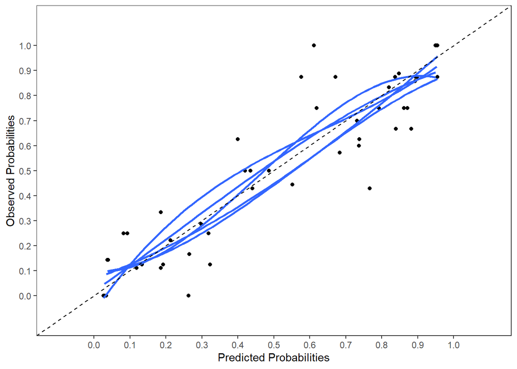

```r
library(psfmi)

 res_extval <- mivalext_lr(data.val = lbpmi_extval, nimp = 5, impvar = "Impnr",
  Outcome = "Chronic", predictors = pool_lr$predictors_final,
  lp.orig = c(res$int_adj, res$coef_shrink_pooled),
  cal.plot = TRUE)
```

```r
 res_extval$ROC
```

```
## $`ROC (logit)`
##             95% Low    AUC 95% Up
## AUC (logit)  0.7365 0.8477 0.9173
##
## $`ROC (median)`
## 1st Qu.  Median 3rd Qu.
## 0.84678 0.84772 0.85366
```

```r
 res_extval$R2_fixed
```

```
## $`Fisher Z (fixed)`
## [1] 0.45526
##
## $`Median (fixed)`
## 1st Qu.  Median 3rd Qu.
## 0.45742 0.45831 0.47240
```

```r
 res_extval$HLtest
```

```
##         D         p        df       df2
##   0.89517   0.52245   8.00000 138.64820
```

```r
 res_extval$LP_pooled_ext
```

```
## intercept     slope
##   0.00589   0.87747
```

Back to Steps